# Respirometry

EL Strand

6/10/2020

Load required packages.

```r
## Installing if package is not already downloaded
if ("devtools" %in% rownames(installed.packages()) == 'FALSE') install.packages('devtools')
library(devtools)
```

```r
if ("segmented" %in% rownames(installed.packages()) == 'FALSE') install.packages('segmented')
if ("plotrix" %in% rownames(installed.packages()) == 'FALSE') install.packages('plotrix')
if ("gridExtra" %in% rownames(installed.packages()) == 'FALSE') install.packages('gridExtra')
if ("LoLinR" %in% rownames(installed.packages()) == 'FALSE') install_github('colin-olito/LoLinR')
if ("lubridate" %in% rownames(installed.packages()) == 'FALSE') install.packages('lubridate')
if ("chron" %in% rownames(installed.packages()) == 'FALSE') install.packages('chron')
if ("plyr" %in% rownames(installed.packages()) == 'FALSE') install.packages('plyr')
if ("dplyr" %in% rownames(installed.packages()) == 'FALSE') install.packages('dplyr')
if ("ggpubr" %in% rownames(installed.packages()) == 'FALSE') install.packages('ggpubr')
if ("car" %in% rownames(installed.packages()) == 'FALSE') install.packages('car')

## Read in libraries.
install_github('colin-olito/LoLinR')
```

```
## Skipping install of 'LoLinR' from a github remote, the SHA1 (2f30b80c) has not changed since last install.
##   Use `force = TRUE` to force installation
```

```r
library("ggplot2")
library("segmented")
library("plotrix")
library("gridExtra")
library("LoLinR")
library("lubridate")
library("chron")
library('plyr')
library('dplyr')
library('stringr')
library("ggpubr")
library("car")
```

Load in respiration files and creating a blank data frame to be filled in by calculated data later on.

```r
path.p <- "Physiology_variables/Respirometry/Raw_Data/" #the location of all your respirometry files

file.names <- basename(list.files(path = path.p, pattern = "csv$", recursive = TRUE)) #list all csv file names in the folder and subfolders
#basename above removes the subdirectory name from the file

#generate a 3 column dataframe with specific column names
Photo.R <- data.frame(matrix(NA, nrow=length(file.names)*2, ncol=3))
colnames(Photo.R) <- c("Fragment.ID","Intercept", "umol.L.sec")

#add file names that include the subdirectory name
file.names.full <- list.files(path = path.p, pattern = "csv$", recursive = TRUE) #list all csv file names in the folder and subfolders
```

Calculating respiration rates.

```r
PR <- c('Photo', 'Resp')

for(i in 1:length(file.names.full)) { # for every file in list start at the first and run this following function
  Photo.Data1 <-read.table(file.path(path.p,file.names.full[i]), skip = 1, header=T, sep=",", na.string="NA", fill = TRUE, as.is=TRUE, fileEncoding="latin1") #reads in the data files
  Photo.Data1 <- Photo.Data1[with(Photo.Data1, order(Time)), ]
  Photo.Data1  <- Photo.Data1[,c(2,9,16)] #subset columns of interest
  n<-dim(Photo.Data1)[1] #identify length of data
  Photo.Data1 <-Photo.Data1[120:(n-3),] #start at data point ~2 minute in to avoid excess noise from start of run and remove last 3 lines containing text
  Photo.Data1$Time <- as.POSIXct(Photo.Data1$Time,format="%H:%M:%S", tz = "") #convert time from character to time
  Photo.Data1$x <- as.numeric(rownames(Photo.Data1))
  brk <- which(diff(Photo.Data1$Time) > 30) #look for breaks in time of x seconds or more
  brk <- Photo.Data1[brk,4]
  Photo <- subset(Photo.Data1, as.numeric(rownames(Photo.Data1)) < brk[1])  #subset by break in time stamp keeping everything before break
  Resp <- subset(Photo.Data1, as.numeric(rownames(Photo.Data1)) > brk[1]) #subset by break in time stamp keeping everything before break
  lt.levs <- list(Photo, Resp) #list levels of segmentation

  for(j in 1:length(lt.levs)){
    Photo.Data <- as.data.frame(lt.levs[j])
    n<-dim(Photo.Data )[1] #identify length of data
    #Photo.Data <-Photo.Data [120:(n-3),] #start at data point ~2 minute in to avoid excess noise from start of run and remove last 3 lines containing text
    #n<-dim(Photo.Data )[1] #list length of trimmed data
    Photo.Data$sec <- 1:n #set seconds by one from start to finish of run

    #Save plot prior to and after data thinning to make sure thinning is not too extreme
    rename <- sub(".csv", "", file.names[i])
    pdf(paste0("Physiology_variables/Respirometry/Output/Data_thinning/",rename,"_",j,"thinning.pdf"))
    par(omi=rep(0.3, 4)) #set size of the outer margins in inches
    par(mfrow=c(1,2)) #set number of rows and columns in multi plot graphic
    plot(Value ~ sec, data=Photo.Data , xlab='Time (seconds)', ylab=substitute(' O'[2]~' (µmol/L)'), type='n', axes=FALSE) #plot data as a function of time
    usr  <-  par('usr')
    rect(usr[1], usr[3], usr[2], usr[4], col='grey90', border=NA)
    whiteGrid()
    box()
    points(Photo.Data$Value ~ Photo.Data $sec, pch=16, col=transparentColor('dodgerblue2', 0.6), cex=1.1)
    axis(1)
    axis(2, las=1)

    #save original unthinned and thinned data figure for comparison
    thin <- 30
    alp <- 0.2
    Photo.Data.orig<-Photo.Data
    Photo.Data <-  thinData(Photo.Data ,by=thin)$newData1 #thin data by every x points for all the O2 values
    Photo.Data$sec <- as.numeric(rownames(Photo.Data)) #maintain numeric values for time
    Photo.Data$Temp<-NA
    Photo.Data$Temp <-  thinData(Photo.Data.orig,xy = c(1,3),by=thin)$newData1[,2] #thin data by every 20 points for the temp values

    plot(Value ~ sec, data=Photo.Data , xlab='Time (seconds)', ylab=substitute(' O'[2]~' (µmol/L)'), type='n', axes=FALSE) #plot thinned data
    usr  <-  par('usr') #plotting graphics using 'usr'
    rect(usr[1], usr[3], usr[2], usr[4], col='grey90', border=NA) #giving specific coordinates for plot using 'usr'
    whiteGrid()
    box()
    points(Photo.Data$Value ~ Photo.Data$sec, pch=16, col=transparentColor('dodgerblue2', 0.6), cex=1.1)
    axis(1)
    axis(2, las=1)
    dev.off()

    ##Olito et al. 2017: It is running a bootstrapping technique and calculating the rate based on density
    Regs  <-  rankLocReg(xall=Photo.Data $sec, yall=Photo.Data $Value, alpha=alp,
                         method="pc", verbose=TRUE)
    pdf(paste0("Physiology_variables/Respirometry/Output/Regressions/",rename,"_",j,"regression.pdf"))
    plot(Regs)
    dev.off()

    s <- seq(0,nrow(Photo.R),length(lt.levs)) #to order the file output sequence in correct order in data frame
    Photo.R[j+s[i],2:3] <- Regs$allRegs[1,c(4,5)] #inserts slope and intercept in the dataframe
    Photo.R[j+s[i],1] <- rename #stores the file name in the Date column
    Photo.R[j+s[i],1] <- paste0(rename,"_",j) #stores the file name in the Date column
    Photo.R[j+s[i],4] <- mean(Photo.Data$Temp, na.rm=T)  #stores the Temperature in the Temp.C column
    Photo.R[j+s[i],5] <- PR[j] #stores whether it is photosynthesis or respiration
  }
}
```

```
## rankLocReg fitted 2346 local regressions
```

```
## rankLocReg fitted 4278 local regressions
```

```
## rankLocReg fitted 2346 local regressions
```

```
## rankLocReg fitted 4278 local regressions
```

```
## rankLocReg fitted 2080 local regressions
```

```
## rankLocReg fitted 1378 local regressions
```

```
## rankLocReg fitted 2145 local regressions
```

```
## rankLocReg fitted 1378 local regressions
```

```
## rankLocReg fitted 1711 local regressions
```

```
## rankLocReg fitted 2346 local regressions
```

```
## rankLocReg fitted 1711 local regressions
```

```
## rankLocReg fitted 2278 local regressions
```

```
## rankLocReg fitted 2346 local regressions
```

```
## rankLocReg fitted 4278 local regressions
```

```
## rankLocReg fitted 2080 local regressions
```

```
## rankLocReg fitted 1378 local regressions
```

```
## rankLocReg fitted 2080 local regressions
```

```
## rankLocReg fitted 1378 local regressions
```

```
## rankLocReg fitted 2080 local regressions
```

```
## rankLocReg fitted 1378 local regressions
```

```
## rankLocReg fitted 1711 local regressions
```

```
## rankLocReg fitted 2278 local regressions
```

```
## rankLocReg fitted 2346 local regressions
```

```
## rankLocReg fitted 4278 local regressions
```

```
## rankLocReg fitted 2080 local regressions
```

```
## rankLocReg fitted 1378 local regressions
```

```
## rankLocReg fitted 1711 local regressions
```

```
## rankLocReg fitted 2346 local regressions
```

```
## rankLocReg fitted 2346 local regressions
```

```
## rankLocReg fitted 4278 local regressions
```

```
## rankLocReg fitted 2346 local regressions
```

```
## rankLocReg fitted 4278 local regressions
```

```
## rankLocReg fitted 1711 local regressions
```

```
## rankLocReg fitted 2346 local regressions
```

```
## rankLocReg fitted 1711 local regressions
```

```
## rankLocReg fitted 2346 local regressions
```

```
## rankLocReg fitted 2145 local regressions
```

```
## rankLocReg fitted 1378 local regressions
```

```
## rankLocReg fitted 2346 local regressions
```

```
## rankLocReg fitted 4278 local regressions
```

```
## rankLocReg fitted 2346 local regressions
```

```
## rankLocReg fitted 4278 local regressions
```

```
## rankLocReg fitted 2080 local regressions
```

```
## rankLocReg fitted 1378 local regressions
```

```
## rankLocReg fitted 2145 local regressions
```

```
## rankLocReg fitted 1378 local regressions
```

```
## rankLocReg fitted 2080 local regressions
```

```
## rankLocReg fitted 1378 local regressions
```

```
## rankLocReg fitted 1711 local regressions
```

```
## rankLocReg fitted 2278 local regressions
```

```
## rankLocReg fitted 2346 local regressions
```

```
## rankLocReg fitted 4278 local regressions
```

```
## rankLocReg fitted 1711 local regressions
```

```
## rankLocReg fitted 2346 local regressions
```

```
## rankLocReg fitted 1711 local regressions
```

```
## rankLocReg fitted 2346 local regressions
```

```
## rankLocReg fitted 1711 local regressions
```

```
## rankLocReg fitted 2278 local regressions
```

```
## rankLocReg fitted 2346 local regressions
```

```
## rankLocReg fitted 4278 local regressions
```

```
## rankLocReg fitted 351 local regressions
```

```
## rankLocReg fitted 820 local regressions
```

```
## rankLocReg fitted 351 local regressions
```

```
## rankLocReg fitted 820 local regressions
```

```
## rankLocReg fitted 276 local regressions
```

```
## rankLocReg fitted 666 local regressions
```

```
## rankLocReg fitted 300 local regressions
```

```
## rankLocReg fitted 666 local regressions
```

```
## rankLocReg fitted 300 local regressions
```

```
## rankLocReg fitted 946 local regressions
```

```
## rankLocReg fitted 300 local regressions
```

```
## rankLocReg fitted 946 local regressions
```

```
## rankLocReg fitted 325 local regressions
```

```
## rankLocReg fitted 1540 local regressions
```

```
## rankLocReg fitted 325 local regressions
```

```
## rankLocReg fitted 1540 local regressions
```

```
## rankLocReg fitted 406 local regressions
```

```
## rankLocReg fitted 630 local regressions
```

```
## rankLocReg fitted 406 local regressions
```

```
## rankLocReg fitted 595 local regressions
```

```
## rankLocReg fitted 496 local regressions
```

```
## rankLocReg fitted 1035 local regressions
```

```
## rankLocReg fitted 496 local regressions
```

```
## rankLocReg fitted 990 local regressions
```

```
## rankLocReg fitted 325 local regressions
```

```
## rankLocReg fitted 1540 local regressions
```

```
## rankLocReg fitted 325 local regressions
```

```
## rankLocReg fitted 1540 local regressions
```

```
## rankLocReg fitted 406 local regressions
```

```
## rankLocReg fitted 595 local regressions
```

```
## rankLocReg fitted 406 local regressions
```

```
## rankLocReg fitted 595 local regressions
```

```
## rankLocReg fitted 496 local regressions
```

```
## rankLocReg fitted 1035 local regressions
```

```
## rankLocReg fitted 351 local regressions
```

```
## rankLocReg fitted 820 local regressions
```

```
## rankLocReg fitted 496 local regressions
```

```
## rankLocReg fitted 1035 local regressions
```

```
## rankLocReg fitted 406 local regressions
```

```
## rankLocReg fitted 630 local regressions
```

```
## rankLocReg fitted 325 local regressions
```

```
## rankLocReg fitted 1540 local regressions
```

```
## rankLocReg fitted 300 local regressions
```

```
## rankLocReg fitted 666 local regressions
```

```
## rankLocReg fitted 406 local regressions
```

```
## rankLocReg fitted 630 local regressions
```

```
## rankLocReg fitted 496 local regressions
```

```
## rankLocReg fitted 1035 local regressions
```

```
## rankLocReg fitted 496 local regressions
```

```
## rankLocReg fitted 1035 local regressions
```

```
## rankLocReg fitted 300 local regressions
```

```
## rankLocReg fitted 666 local regressions
```

```
## rankLocReg fitted 300 local regressions
```

```
## rankLocReg fitted 666 local regressions
```

```
## rankLocReg fitted 300 local regressions
```

```
## rankLocReg fitted 946 local regressions
```

```
## rankLocReg fitted 351 local regressions
```

```
## rankLocReg fitted 820 local regressions
```

```
## rankLocReg fitted 276 local regressions
```

```
## rankLocReg fitted 666 local regressions
```

```
## rankLocReg fitted 325 local regressions
```

```
## rankLocReg fitted 1540 local regressions
```

```
## rankLocReg fitted 300 local regressions
```

```
## rankLocReg fitted 946 local regressions
```

```
## rankLocReg fitted 351 local regressions
```

```
## rankLocReg fitted 820 local regressions
```

```
## rankLocReg fitted 351 local regressions
```

```
## rankLocReg fitted 820 local regressions
```

```
## rankLocReg fitted 300 local regressions
```

```
## rankLocReg fitted 946 local regressions
```

```
## rankLocReg fitted 300 local regressions
```

```
## rankLocReg fitted 946 local regressions
```

```
## rankLocReg fitted 325 local regressions
```

```
## rankLocReg fitted 1540 local regressions
```

```
## rankLocReg fitted 406 local regressions
```

```
## rankLocReg fitted 595 local regressions
```

```
## rankLocReg fitted 325 local regressions
```

```
## rankLocReg fitted 1540 local regressions
```

```
## rankLocReg fitted 406 local regressions
```

```
## rankLocReg fitted 595 local regressions
```

```
## rankLocReg fitted 406 local regressions
```

```
## rankLocReg fitted 630 local regressions
```

```
## rankLocReg fitted 496 local regressions
```

```
## rankLocReg fitted 1035 local regressions
```

```
## rankLocReg fitted 406 local regressions
```

```
## rankLocReg fitted 595 local regressions
```

```
## rankLocReg fitted 496 local regressions
```

```
## rankLocReg fitted 990 local regressions
```

```
## rankLocReg fitted 351 local regressions
```

```
## rankLocReg fitted 820 local regressions
```

```
## rankLocReg fitted 276 local regressions
```

```
## rankLocReg fitted 666 local regressions
```

```
## rankLocReg fitted 300 local regressions
```

```
## rankLocReg fitted 666 local regressions
```

```
## rankLocReg fitted 325 local regressions
```

```
## rankLocReg fitted 1540 local regressions
```

```
## rankLocReg fitted 496 local regressions
```

```
## rankLocReg fitted 1035 local regressions
```

```
## rankLocReg fitted 496 local regressions
```

```
## rankLocReg fitted 1035 local regressions
```

```
## rankLocReg fitted 325 local regressions
```

```
## rankLocReg fitted 820 local regressions
```

```
## rankLocReg fitted 300 local regressions
```

```
## rankLocReg fitted 666 local regressions
```

```
## rankLocReg fitted 300 local regressions
```

```
## rankLocReg fitted 666 local regressions
```

```
## rankLocReg fitted 351 local regressions
```

```
## rankLocReg fitted 820 local regressions
```

```
## rankLocReg fitted 325 local regressions
```

```
## rankLocReg fitted 1540 local regressions
```

```
## rankLocReg fitted 300 local regressions
```

```
## rankLocReg fitted 946 local regressions
```

```
## rankLocReg fitted 300 local regressions
```

```
## rankLocReg fitted 946 local regressions
```

```
## rankLocReg fitted 351 local regressions
```

```
## rankLocReg fitted 820 local regressions
```

```
## rankLocReg fitted 300 local regressions
```

```
## rankLocReg fitted 946 local regressions
```

```
## rankLocReg fitted 300 local regressions
```

```
## rankLocReg fitted 946 local regressions
```

```
## rankLocReg fitted 300 local regressions
```

```
## rankLocReg fitted 630 local regressions
```

```
## rankLocReg fitted 325 local regressions
```

```
## rankLocReg fitted 666 local regressions
```

```
## rankLocReg fitted 253 local regressions
```

```
## rankLocReg fitted 406 local regressions
```

```
## rankLocReg fitted 253 local regressions
```

```
## rankLocReg fitted 406 local regressions
```

```
## rankLocReg fitted 120 local regressions
```

```
## rankLocReg fitted 465 local regressions
```

```
## rankLocReg fitted 120 local regressions
```

```
## rankLocReg fitted 435 local regressions
```

```
## rankLocReg fitted 300 local regressions
```

```
## rankLocReg fitted 528 local regressions
```

```
## rankLocReg fitted 300 local regressions
```

```
## rankLocReg fitted 528 local regressions
```

```
## rankLocReg fitted 406 local regressions
```

```
## rankLocReg fitted 406 local regressions
```

```
## rankLocReg fitted 406 local regressions
```

```
## rankLocReg fitted 406 local regressions
```

```
## rankLocReg fitted 253 local regressions
```

```
## rankLocReg fitted 465 local regressions
```

```
## rankLocReg fitted 253 local regressions
```

```
## rankLocReg fitted 465 local regressions
```

```
## rankLocReg fitted 300 local regressions
```

```
## rankLocReg fitted 630 local regressions
```

```
## rankLocReg fitted 253 local regressions
```

```
## rankLocReg fitted 406 local regressions
```

```
## rankLocReg fitted 300 local regressions
```

```
## rankLocReg fitted 630 local regressions
```

```
## rankLocReg fitted 253 local regressions
```

```
## rankLocReg fitted 406 local regressions
```

```
## rankLocReg fitted 120 local regressions
```

```
## rankLocReg fitted 435 local regressions
```

```
## rankLocReg fitted 406 local regressions
```

```
## rankLocReg fitted 406 local regressions
```

```
## rankLocReg fitted 253 local regressions
```

```
## rankLocReg fitted 406 local regressions
```

```
## rankLocReg fitted 253 local regressions
```

```
## rankLocReg fitted 406 local regressions
```

```
## rankLocReg fitted 406 local regressions
```

```
## rankLocReg fitted 406 local regressions
```

```
## rankLocReg fitted 136 local regressions
```

```
## rankLocReg fitted 465 local regressions
```

```
## rankLocReg fitted 120 local regressions
```

```
## rankLocReg fitted 435 local regressions
```

```
## rankLocReg fitted 253 local regressions
```

```
## rankLocReg fitted 496 local regressions
```

```
## rankLocReg fitted 406 local regressions
```

```
## rankLocReg fitted 406 local regressions
```

```
## rankLocReg fitted 325 local regressions
```

```
## rankLocReg fitted 630 local regressions
```

```
## rankLocReg fitted 300 local regressions
```

```
## rankLocReg fitted 528 local regressions
```

```
## rankLocReg fitted 300 local regressions
```

```
## rankLocReg fitted 528 local regressions
```

```
## rankLocReg fitted 406 local regressions
```

```
## rankLocReg fitted 406 local regressions
```

```
## rankLocReg fitted 325 local regressions
```

```
## rankLocReg fitted 666 local regressions
```

```
## rankLocReg fitted 300 local regressions
```

```
## rankLocReg fitted 528 local regressions
```

```
## rankLocReg fitted 300 local regressions
```

```
## rankLocReg fitted 528 local regressions
```

```
## rankLocReg fitted 253 local regressions
```

```
## rankLocReg fitted 465 local regressions
```

```
## rankLocReg fitted 120 local regressions
```

```
## rankLocReg fitted 435 local regressions
```

```
## rankLocReg fitted 253 local regressions
```

```
## rankLocReg fitted 465 local regressions
```

```
## rankLocReg fitted 253 local regressions
```

```
## rankLocReg fitted 465 local regressions
```

```
## rankLocReg fitted 300 local regressions
```

```
## rankLocReg fitted 630 local regressions
```

```
## rankLocReg fitted 300 local regressions
```

```
## rankLocReg fitted 630 local regressions
```

```
## rankLocReg fitted 120 local regressions
```

```
## rankLocReg fitted 435 local regressions
```

```
## rankLocReg fitted 253 local regressions
```

```
## rankLocReg fitted 406 local regressions
```

```
## rankLocReg fitted 253 local regressions
```

```
## rankLocReg fitted 406 local regressions
```

```
## rankLocReg fitted 120 local regressions
```

```
## rankLocReg fitted 435 local regressions
```

```
## rankLocReg fitted 253 local regressions
```

```
## rankLocReg fitted 406 local regressions
```

```
## rankLocReg fitted 300 local regressions
```

```
## rankLocReg fitted 528 local regressions
```

```
## rankLocReg fitted 253 local regressions
```

```
## rankLocReg fitted 406 local regressions
```

```
## rankLocReg fitted 300 local regressions
```

```
## rankLocReg fitted 528 local regressions
```

```
## rankLocReg fitted 406 local regressions
```

```
## rankLocReg fitted 406 local regressions
```

```
## rankLocReg fitted 300 local regressions
```

```
## rankLocReg fitted 630 local regressions
```

```
## rankLocReg fitted 406 local regressions
```

```
## rankLocReg fitted 406 local regressions
```

```
## rankLocReg fitted 325 local regressions
```

```
## rankLocReg fitted 666 local regressions
```

```
## rankLocReg fitted 120 local regressions
```

```
## rankLocReg fitted 465 local regressions
```

```
## rankLocReg fitted 406 local regressions
```

```
## rankLocReg fitted 406 local regressions
```

```
## rankLocReg fitted 253 local regressions
```

```
## rankLocReg fitted 465 local regressions
```

```
## rankLocReg fitted 136 local regressions
```

```
## rankLocReg fitted 465 local regressions
```

```
## rankLocReg fitted 406 local regressions
```

```
## rankLocReg fitted 406 local regressions
```

```
## rankLocReg fitted 253 local regressions
```

```
## rankLocReg fitted 465 local regressions
```

```
## rankLocReg fitted 300 local regressions
```

```
## rankLocReg fitted 528 local regressions
```

```
## rankLocReg fitted 300 local regressions
```

```
## rankLocReg fitted 528 local regressions
```

```
## rankLocReg fitted 253 local regressions
```

```
## rankLocReg fitted 465 local regressions
```

```
## rankLocReg fitted 253 local regressions
```

```
## rankLocReg fitted 465 local regressions
```

```
## rankLocReg fitted 325 local regressions
```

```
## rankLocReg fitted 703 local regressions
```

```
## rankLocReg fitted 325 local regressions
```

```
## rankLocReg fitted 703 local regressions
```

```
## rankLocReg fitted 276 local regressions
```

```
## rankLocReg fitted 465 local regressions
```

```
## rankLocReg fitted 276 local regressions
```

```
## rankLocReg fitted 465 local regressions
```

```
## rankLocReg fitted 300 local regressions
```

```
## rankLocReg fitted 5886 local regressions
```

```
## rankLocReg fitted 300 local regressions
```

```
## rankLocReg fitted 5886 local regressions
```

```
## rankLocReg fitted 300 local regressions
```

```
## rankLocReg fitted 666 local regressions
```

```
## rankLocReg fitted 300 local regressions
```

```
## rankLocReg fitted 630 local regressions
```

```
## rankLocReg fitted 378 local regressions
```

```
## rankLocReg fitted 666 local regressions
```

```
## rankLocReg fitted 378 local regressions
```

```
## rankLocReg fitted 703 local regressions
```

```
## rankLocReg fitted 231 local regressions
```

```
## rankLocReg fitted 595 local regressions
```

```
## rankLocReg fitted 231 local regressions
```

```
## rankLocReg fitted 595 local regressions
```

```
## rankLocReg fitted 325 local regressions
```

```
## rankLocReg fitted 703 local regressions
```

```
## rankLocReg fitted 325 local regressions
```

```
## rankLocReg fitted 703 local regressions
```

```
## rankLocReg fitted 276 local regressions
```

```
## rankLocReg fitted 465 local regressions
```

```
## rankLocReg fitted 276 local regressions
```

```
## rankLocReg fitted 465 local regressions
```

```
## rankLocReg fitted 276 local regressions
```

```
## rankLocReg fitted 465 local regressions
```

```
## rankLocReg fitted 300 local regressions
```

```
## rankLocReg fitted 5886 local regressions
```

```
## rankLocReg fitted 300 local regressions
```

```
## rankLocReg fitted 5886 local regressions
```

```
## rankLocReg fitted 276 local regressions
```

```
## rankLocReg fitted 465 local regressions
```

```
## rankLocReg fitted 300 local regressions
```

```
## rankLocReg fitted 630 local regressions
```

```
## rankLocReg fitted 325 local regressions
```

```
## rankLocReg fitted 703 local regressions
```

```
## rankLocReg fitted 406 local regressions
```

```
## rankLocReg fitted 703 local regressions
```

```
## rankLocReg fitted 378 local regressions
```

```
## rankLocReg fitted 666 local regressions
```

```
## rankLocReg fitted 351 local regressions
```

```
## rankLocReg fitted 666 local regressions
```

```
## rankLocReg fitted 325 local regressions
```

```
## rankLocReg fitted 703 local regressions
```

```
## rankLocReg fitted 231 local regressions
```

```
## rankLocReg fitted 595 local regressions
```

```
## rankLocReg fitted 231 local regressions
```

```
## rankLocReg fitted 595 local regressions
```

```
## rankLocReg fitted 300 local regressions
```

```
## rankLocReg fitted 5886 local regressions
```

```
## rankLocReg fitted 231 local regressions
```

```
## rankLocReg fitted 595 local regressions
```

```
## rankLocReg fitted 300 local regressions
```

```
## rankLocReg fitted 630 local regressions
```

```
## rankLocReg fitted 300 local regressions
```

```
## rankLocReg fitted 630 local regressions
```

```
## rankLocReg fitted 300 local regressions
```

```
## rankLocReg fitted 5886 local regressions
```

```
## rankLocReg fitted 378 local regressions
```

```
## rankLocReg fitted 703 local regressions
```

```
## rankLocReg fitted 300 local regressions
```

```
## rankLocReg fitted 630 local regressions
```

```
## rankLocReg fitted 231 local regressions
```

```
## rankLocReg fitted 595 local regressions
```

```
## rankLocReg fitted 325 local regressions
```

```
## rankLocReg fitted 703 local regressions
```

```
## rankLocReg fitted 276 local regressions
```

```
## rankLocReg fitted 465 local regressions
```

```
## rankLocReg fitted 276 local regressions
```

```
## rankLocReg fitted 465 local regressions
```

```
## rankLocReg fitted 276 local regressions
```

```
## rankLocReg fitted 465 local regressions
```

```
## rankLocReg fitted 325 local regressions
```

```
## rankLocReg fitted 703 local regressions
```

```
## rankLocReg fitted 276 local regressions
```

```
## rankLocReg fitted 465 local regressions
```

```
## rankLocReg fitted 300 local regressions
```

```
## rankLocReg fitted 5886 local regressions
```

```
## rankLocReg fitted 300 local regressions
```

```
## rankLocReg fitted 5886 local regressions
```

```
## rankLocReg fitted 300 local regressions
```

```
## rankLocReg fitted 630 local regressions
```

```
## rankLocReg fitted 325 local regressions
```

```
## rankLocReg fitted 703 local regressions
```

```
## rankLocReg fitted 378 local regressions
```

```
## rankLocReg fitted 666 local regressions
```

```
## rankLocReg fitted 325 local regressions
```

```
## rankLocReg fitted 703 local regressions
```

```
## rankLocReg fitted 300 local regressions
```

```
## rankLocReg fitted 630 local regressions
```

```
## rankLocReg fitted 378 local regressions
```

```
## rankLocReg fitted 666 local regressions
```

```
## rankLocReg fitted 300 local regressions
```

```
## rankLocReg fitted 5886 local regressions
```

```
## rankLocReg fitted 378 local regressions
```

```
## rankLocReg fitted 666 local regressions
```

```
## rankLocReg fitted 231 local regressions
```

```
## rankLocReg fitted 595 local regressions
```

```
## rankLocReg fitted 300 local regressions
```

```
## rankLocReg fitted 5886 local regressions
```

```
## rankLocReg fitted 231 local regressions
```

```
## rankLocReg fitted 595 local regressions
```

```
## rankLocReg fitted 378 local regressions
```

```
## rankLocReg fitted 666 local regressions
```

```
## rankLocReg fitted 300 local regressions
```

```
## rankLocReg fitted 630 local regressions
```

```
## rankLocReg fitted 300 local regressions
```

```
## rankLocReg fitted 630 local regressions
```

```
## rankLocReg fitted 231 local regressions
```

```
## rankLocReg fitted 595 local regressions
```

```
## rankLocReg fitted 231 local regressions
```

```
## rankLocReg fitted 595 local regressions
```

```
## rankLocReg fitted 253 local regressions
```

```
## rankLocReg fitted 703 local regressions
```

```
## rankLocReg fitted 253 local regressions
```

```
## rankLocReg fitted 703 local regressions
```

```
## rankLocReg fitted 253 local regressions
```

```
## rankLocReg fitted 496 local regressions
```

```
## rankLocReg fitted 253 local regressions
```

```
## rankLocReg fitted 496 local regressions
```

```
## rankLocReg fitted 276 local regressions
```

```
## rankLocReg fitted 666 local regressions
```

```
## rankLocReg fitted 276 local regressions
```

```
## rankLocReg fitted 666 local regressions
```

```
## rankLocReg fitted 351 local regressions
```

```
## rankLocReg fitted 741 local regressions
```

```
## rankLocReg fitted 351 local regressions
```

```
## rankLocReg fitted 741 local regressions
```

```
## rankLocReg fitted 351 local regressions
```

```
## rankLocReg fitted 703 local regressions
```

```
## rankLocReg fitted 351 local regressions
```

```
## rankLocReg fitted 703 local regressions
```

```
## rankLocReg fitted 300 local regressions
```

```
## rankLocReg fitted 1081 local regressions
```

```
## rankLocReg fitted 300 local regressions
```

```
## rankLocReg fitted 1081 local regressions
```

```
## rankLocReg fitted 253 local regressions
```

```
## rankLocReg fitted 703 local regressions
```

```
## rankLocReg fitted 253 local regressions
```

```
## rankLocReg fitted 703 local regressions
```

```
## rankLocReg fitted 253 local regressions
```

```
## rankLocReg fitted 496 local regressions
```

```
## rankLocReg fitted 253 local regressions
```

```
## rankLocReg fitted 496 local regressions
```

```
## rankLocReg fitted 253 local regressions
```

```
## rankLocReg fitted 496 local regressions
```

```
## rankLocReg fitted 351 local regressions
```

```
## rankLocReg fitted 741 local regressions
```

```
## rankLocReg fitted 276 local regressions
```

```
## rankLocReg fitted 666 local regressions
```

```
## rankLocReg fitted 351 local regressions
```

```
## rankLocReg fitted 741 local regressions
```

```
## rankLocReg fitted 253 local regressions
```

```
## rankLocReg fitted 703 local regressions
```

```
## rankLocReg fitted 253 local regressions
```

```
## rankLocReg fitted 496 local regressions
```

```
## rankLocReg fitted 351 local regressions
```

```
## rankLocReg fitted 703 local regressions
```

```
## rankLocReg fitted 276 local regressions
```

```
## rankLocReg fitted 666 local regressions
```

```
## rankLocReg fitted 276 local regressions
```

```
## rankLocReg fitted 666 local regressions
```

```
## rankLocReg fitted 351 local regressions
```

```
## rankLocReg fitted 741 local regressions
```

```
## rankLocReg fitted 351 local regressions
```

```
## rankLocReg fitted 741 local regressions
```

```
## rankLocReg fitted 276 local regressions
```

```
## rankLocReg fitted 666 local regressions
```

```
## rankLocReg fitted 351 local regressions
```

```
## rankLocReg fitted 703 local regressions
```

```
## rankLocReg fitted 351 local regressions
```

```
## rankLocReg fitted 703 local regressions
```

```
## rankLocReg fitted 276 local regressions
```

```
## rankLocReg fitted 703 local regressions
```

```
## rankLocReg fitted 351 local regressions
```

```
## rankLocReg fitted 703 local regressions
```

```
## rankLocReg fitted 300 local regressions
```

```
## rankLocReg fitted 1081 local regressions
```

```
## rankLocReg fitted 300 local regressions
```

```
## rankLocReg fitted 1081 local regressions
```

```
## rankLocReg fitted 300 local regressions
```

```
## rankLocReg fitted 1081 local regressions
```

```
## rankLocReg fitted 300 local regressions
```

```
## rankLocReg fitted 1081 local regressions
```

```
## rankLocReg fitted 253 local regressions
```

```
## rankLocReg fitted 703 local regressions
```

```
## rankLocReg fitted 253 local regressions
```

```
## rankLocReg fitted 703 local regressions
```

```
## rankLocReg fitted 253 local regressions
```

```
## rankLocReg fitted 496 local regressions
```

```
## rankLocReg fitted 253 local regressions
```

```
## rankLocReg fitted 496 local regressions
```

```
## rankLocReg fitted 253 local regressions
```

```
## rankLocReg fitted 496 local regressions
```

```
## rankLocReg fitted 253 local regressions
```

```
## rankLocReg fitted 496 local regressions
```

```
## rankLocReg fitted 276 local regressions
```

```
## rankLocReg fitted 666 local regressions
```

```
## rankLocReg fitted 351 local regressions
```

```
## rankLocReg fitted 741 local regressions
```

```
## rankLocReg fitted 351 local regressions
```

```
## rankLocReg fitted 741 local regressions
```

```
## rankLocReg fitted 351 local regressions
```

```
## rankLocReg fitted 703 local regressions
```

```
## rankLocReg fitted 276 local regressions
```

```
## rankLocReg fitted 666 local regressions
```

```
## rankLocReg fitted 351 local regressions
```

```
## rankLocReg fitted 703 local regressions
```

```
## rankLocReg fitted 253 local regressions
```

```
## rankLocReg fitted 703 local regressions
```

```
## rankLocReg fitted 300 local regressions
```

```
## rankLocReg fitted 1081 local regressions
```

```
## rankLocReg fitted 351 local regressions
```

```
## rankLocReg fitted 741 local regressions
```

```
## rankLocReg fitted 276 local regressions
```

```
## rankLocReg fitted 666 local regressions
```

```
## rankLocReg fitted 276 local regressions
```

```
## rankLocReg fitted 666 local regressions
```

```
## rankLocReg fitted 351 local regressions
```

```
## rankLocReg fitted 703 local regressions
```

```
## rankLocReg fitted 300 local regressions
```

```
## rankLocReg fitted 1081 local regressions
```

```
## rankLocReg fitted 351 local regressions
```

```
## rankLocReg fitted 703 local regressions
```

```
## rankLocReg fitted 253 local regressions
```

```
## rankLocReg fitted 703 local regressions
```

```
## rankLocReg fitted 351 local regressions
```

```
## rankLocReg fitted 741 local regressions
```

```
## rankLocReg fitted 300 local regressions
```

```
## rankLocReg fitted 1081 local regressions
```

```
## rankLocReg fitted 300 local regressions
```

```
## rankLocReg fitted 1081 local regressions
```

```
## rankLocReg fitted 231 local regressions
```

```
## rankLocReg fitted 528 local regressions
```

```
## rankLocReg fitted 231 local regressions
```

```
## rankLocReg fitted 528 local regressions
```

```
## rankLocReg fitted 325 local regressions
```

```
## rankLocReg fitted 378 local regressions
```

```
## rankLocReg fitted 325 local regressions
```

```
## rankLocReg fitted 378 local regressions
```

```
## rankLocReg fitted 231 local regressions
```

```
## rankLocReg fitted 528 local regressions
```

```
## rankLocReg fitted 231 local regressions
```

```
## rankLocReg fitted 528 local regressions
```

```
## rankLocReg fitted 406 local regressions
```

```
## rankLocReg fitted 903 local regressions
```

```
## rankLocReg fitted 406 local regressions
```

```
## rankLocReg fitted 903 local regressions
```

```
## rankLocReg fitted 378 local regressions
```

```
## rankLocReg fitted 630 local regressions
```

```
## rankLocReg fitted 378 local regressions
```

```
## rankLocReg fitted 630 local regressions
```

```
## rankLocReg fitted 276 local regressions
```

```
## rankLocReg fitted 465 local regressions
```

```
## rankLocReg fitted 276 local regressions
```

```
## rankLocReg fitted 465 local regressions
```

```
## rankLocReg fitted 231 local regressions
```

```
## rankLocReg fitted 528 local regressions
```

```
## rankLocReg fitted 231 local regressions
```

```
## rankLocReg fitted 528 local regressions
```

```
## rankLocReg fitted 325 local regressions
```

```
## rankLocReg fitted 378 local regressions
```

```
## rankLocReg fitted 325 local regressions
```

```
## rankLocReg fitted 378 local regressions
```

```
## rankLocReg fitted 325 local regressions
```

```
## rankLocReg fitted 378 local regressions
```

```
## rankLocReg fitted 231 local regressions
```

```
## rankLocReg fitted 528 local regressions
```

```
## rankLocReg fitted 231 local regressions
```

```
## rankLocReg fitted 528 local regressions
```

```
## rankLocReg fitted 406 local regressions
```

```
## rankLocReg fitted 903 local regressions
```

```
## rankLocReg fitted 406 local regressions
```

```
## rankLocReg fitted 903 local regressions
```

```
## rankLocReg fitted 378 local regressions
```

```
## rankLocReg fitted 630 local regressions
```

```
## rankLocReg fitted 325 local regressions
```

```
## rankLocReg fitted 378 local regressions
```

```
## rankLocReg fitted 231 local regressions
```

```
## rankLocReg fitted 528 local regressions
```

```
## rankLocReg fitted 231 local regressions
```

```
## rankLocReg fitted 528 local regressions
```

```
## rankLocReg fitted 378 local regressions
```

```
## rankLocReg fitted 630 local regressions
```

```
## rankLocReg fitted 231 local regressions
```

```
## rankLocReg fitted 528 local regressions
```

```
## rankLocReg fitted 276 local regressions
```

```
## rankLocReg fitted 465 local regressions
```

```
## rankLocReg fitted 378 local regressions
```

```
## rankLocReg fitted 630 local regressions
```

```
## rankLocReg fitted 276 local regressions
```

```
## rankLocReg fitted 465 local regressions
```

```
## rankLocReg fitted 231 local regressions
```

```
## rankLocReg fitted 528 local regressions
```

```
## rankLocReg fitted 406 local regressions
```

```
## rankLocReg fitted 903 local regressions
```

```
## rankLocReg fitted 406 local regressions
```

```
## rankLocReg fitted 903 local regressions
```

```
## rankLocReg fitted 276 local regressions
```

```
## rankLocReg fitted 465 local regressions
```

```
## rankLocReg fitted 276 local regressions
```

```
## rankLocReg fitted 465 local regressions
```

```
## rankLocReg fitted 231 local regressions
```

```
## rankLocReg fitted 528 local regressions
```

```
## rankLocReg fitted 231 local regressions
```

```
## rankLocReg fitted 528 local regressions
```

```
## rankLocReg fitted 325 local regressions
```

```
## rankLocReg fitted 378 local regressions
```

```
## rankLocReg fitted 325 local regressions
```

```
## rankLocReg fitted 378 local regressions
```

```
## rankLocReg fitted 325 local regressions
```

```
## rankLocReg fitted 378 local regressions
```

```
## rankLocReg fitted 325 local regressions
```

```
## rankLocReg fitted 378 local regressions
```

```
## rankLocReg fitted 231 local regressions
```

```
## rankLocReg fitted 528 local regressions
```

```
## rankLocReg fitted 231 local regressions
```

```
## rankLocReg fitted 528 local regressions
```

```
## rankLocReg fitted 406 local regressions
```

```
## rankLocReg fitted 903 local regressions
```

```
## rankLocReg fitted 231 local regressions
```

```
## rankLocReg fitted 528 local regressions
```

```
## rankLocReg fitted 231 local regressions
```

```
## rankLocReg fitted 528 local regressions
```

```
## rankLocReg fitted 378 local regressions
```

```
## rankLocReg fitted 630 local regressions
```

```
## rankLocReg fitted 276 local regressions
```

```
## rankLocReg fitted 465 local regressions
```

```
## rankLocReg fitted 276 local regressions
```

```
## rankLocReg fitted 465 local regressions
```

```
## rankLocReg fitted 231 local regressions
```

```
## rankLocReg fitted 528 local regressions
```

```
## rankLocReg fitted 406 local regressions
```

```
## rankLocReg fitted 903 local regressions
```

```
## rankLocReg fitted 378 local regressions
```

```
## rankLocReg fitted 630 local regressions
```

```
## rankLocReg fitted 231 local regressions
```

```
## rankLocReg fitted 528 local regressions
```

```
## rankLocReg fitted 378 local regressions
```

```
## rankLocReg fitted 630 local regressions
```

```
## rankLocReg fitted 406 local regressions
```

```
## rankLocReg fitted 903 local regressions
```

```
## rankLocReg fitted 406 local regressions
```

```
## rankLocReg fitted 903 local regressions
```

```
## rankLocReg fitted 276 local regressions
```

```
## rankLocReg fitted 465 local regressions
```

```
## rankLocReg fitted 276 local regressions
```

```
## rankLocReg fitted 465 local regressions
```

```
## rankLocReg fitted 325 local regressions
```

```
## rankLocReg fitted 561 local regressions
```

```
## rankLocReg fitted 325 local regressions
```

```
## rankLocReg fitted 561 local regressions
```

```
## rankLocReg fitted 231 local regressions
```

```
## rankLocReg fitted 528 local regressions
```

```
## rankLocReg fitted 231 local regressions
```

```
## rankLocReg fitted 528 local regressions
```

```
## rankLocReg fitted 231 local regressions
```

```
## rankLocReg fitted 561 local regressions
```

```
## rankLocReg fitted 231 local regressions
```

```
## rankLocReg fitted 561 local regressions
```

```
## rankLocReg fitted 630 local regressions
```

```
## rankLocReg fitted 1128 local regressions
```

```
## rankLocReg fitted 630 local regressions
```

```
## rankLocReg fitted 1128 local regressions
```

```
## rankLocReg fitted 300 local regressions
```

```
## rankLocReg fitted 595 local regressions
```

```
## rankLocReg fitted 300 local regressions
```

```
## rankLocReg fitted 595 local regressions
```

```
## rankLocReg fitted 406 local regressions
```

```
## rankLocReg fitted 465 local regressions
```

```
## rankLocReg fitted 406 local regressions
```

```
## rankLocReg fitted 465 local regressions
```

```
## rankLocReg fitted 325 local regressions
```

```
## rankLocReg fitted 561 local regressions
```

```
## rankLocReg fitted 231 local regressions
```

```
## rankLocReg fitted 528 local regressions
```

```
## rankLocReg fitted 325 local regressions
```

```
## rankLocReg fitted 561 local regressions
```

```
## rankLocReg fitted 231 local regressions
```

```
## rankLocReg fitted 528 local regressions
```

```
## rankLocReg fitted 231 local regressions
```

```
## rankLocReg fitted 561 local regressions
```

```
## rankLocReg fitted 231 local regressions
```

```
## rankLocReg fitted 561 local regressions
```

```
## rankLocReg fitted 300 local regressions
```

```
## rankLocReg fitted 595 local regressions
```

```
## rankLocReg fitted 630 local regressions
```

```
## rankLocReg fitted 1128 local regressions
```

```
## rankLocReg fitted 231 local regressions
```

```
## rankLocReg fitted 561 local regressions
```

```
## rankLocReg fitted 231 local regressions
```

```
## rankLocReg fitted 528 local regressions
```

```
## rankLocReg fitted 325 local regressions
```

```
## rankLocReg fitted 561 local regressions
```

```
## rankLocReg fitted 300 local regressions
```

```
## rankLocReg fitted 595 local regressions
```

```
## rankLocReg fitted 300 local regressions
```

```
## rankLocReg fitted 595 local regressions
```

```
## rankLocReg fitted 300 local regressions
```

```
## rankLocReg fitted 595 local regressions
```

```
## rankLocReg fitted 406 local regressions
```

```
## rankLocReg fitted 465 local regressions
```

```
## rankLocReg fitted 406 local regressions
```

```
## rankLocReg fitted 465 local regressions
```

```
## rankLocReg fitted 231 local regressions
```

```
## rankLocReg fitted 561 local regressions
```

```
## rankLocReg fitted 406 local regressions
```

```
## rankLocReg fitted 465 local regressions
```

```
## rankLocReg fitted 630 local regressions
```

```
## rankLocReg fitted 1128 local regressions
```

```
## rankLocReg fitted 630 local regressions
```

```
## rankLocReg fitted 1128 local regressions
```

```
## rankLocReg fitted 325 local regressions
```

```
## rankLocReg fitted 561 local regressions
```

```
## rankLocReg fitted 630 local regressions
```

```
## rankLocReg fitted 1176 local regressions
```

```
## rankLocReg fitted 406 local regressions
```

```
## rankLocReg fitted 465 local regressions
```

```
## rankLocReg fitted 325 local regressions
```

```
## rankLocReg fitted 561 local regressions
```

```
## rankLocReg fitted 325 local regressions
```

```
## rankLocReg fitted 561 local regressions
```

```
## rankLocReg fitted 231 local regressions
```

```
## rankLocReg fitted 528 local regressions
```

```
## rankLocReg fitted 231 local regressions
```

```
## rankLocReg fitted 528 local regressions
```

```
## rankLocReg fitted 231 local regressions
```

```
## rankLocReg fitted 528 local regressions
```

```
## rankLocReg fitted 231 local regressions
```

```
## rankLocReg fitted 528 local regressions
```

```
## rankLocReg fitted 231 local regressions
```

```
## rankLocReg fitted 561 local regressions
```

```
## rankLocReg fitted 630 local regressions
```

```
## rankLocReg fitted 1128 local regressions
```

```
## rankLocReg fitted 231 local regressions
```

```
## rankLocReg fitted 528 local regressions
```

```
## rankLocReg fitted 325 local regressions
```

```
## rankLocReg fitted 561 local regressions
```

```
## rankLocReg fitted 630 local regressions
```

```
## rankLocReg fitted 1128 local regressions
```

```
## rankLocReg fitted 300 local regressions
```

```
## rankLocReg fitted 595 local regressions
```

```
## rankLocReg fitted 300 local regressions
```

```
## rankLocReg fitted 595 local regressions
```

```
## rankLocReg fitted 231 local regressions
```

```
## rankLocReg fitted 561 local regressions
```

```
## rankLocReg fitted 300 local regressions
```

```
## rankLocReg fitted 595 local regressions
```

```
## rankLocReg fitted 406 local regressions
```

```
## rankLocReg fitted 465 local regressions
```

```
## rankLocReg fitted 300 local regressions
```

```
## rankLocReg fitted 595 local regressions
```

```
## rankLocReg fitted 630 local regressions
```

```
## rankLocReg fitted 1128 local regressions
```

```
## rankLocReg fitted 406 local regressions
```

```
## rankLocReg fitted 465 local regressions
```

```
## rankLocReg fitted 231 local regressions
```

```
## rankLocReg fitted 561 local regressions
```

```
## rankLocReg fitted 325 local regressions
```

```
## rankLocReg fitted 561 local regressions
```

```
## rankLocReg fitted 231 local regressions
```

```
## rankLocReg fitted 561 local regressions
```

```
## rankLocReg fitted 630 local regressions
```

```
## rankLocReg fitted 1176 local regressions
```

```
## rankLocReg fitted 406 local regressions
```

```
## rankLocReg fitted 465 local regressions
```

```
## rankLocReg fitted 406 local regressions
```

```
## rankLocReg fitted 465 local regressions
```

```r
write.csv(Photo.R, 'Physiology_variables/Respirometry/Output/Photo.R.csv')
```

Reading the dataframe in to skip calculating all regressions each time.

```r
Photo.R <- read.csv(file="Physiology_variables/Respirometry/Output/Photo.R.csv", header=T) #read in volume and sample.info data
Photo.R <- Photo.R[,-1]

Photo.R$Fragment.ID <- str_sub(Photo.R$Fragment.ID, 1, str_length(Photo.R$Fragment.ID)-2) #Removing _1 or _2
```

Load sample info spreadsheet in and merge with Photo.R file.

```r
#Load Sample Info
Sample.Info <- read.csv(file="Physiology_variables/Respirometry/Resp_DeltaTA_datasheet.csv", header=T) #read sample.info data
Sample.Info$Fragment.ID <- sub(".csv", "", Sample.Info$Fragment.ID)
Sample.Info$Blnk.Group <- paste(Sample.Info$Date, Sample.Info$Tank, Sample.Info$Light.or.Dark, sep = "_")
Sample.Info$Merge.ID <- paste(Sample.Info$Fragment.ID, Sample.Info$Light.or.Dark, sep = "_")

#Merge data with sample info
colnames(Photo.R) <- c("Fragment.ID", "Intercept","umol.L.sec", "Temp","Light.or.Dark" )
Photo.R$Merge.ID <- paste(Photo.R$Fragment.ID, Photo.R$Light.or.Dark, sep = "_")
Data <- merge(Photo.R,Sample.Info, by="Merge.ID" )
```

Account for chamber volume to convert from umol L-1 s-1 to umol s-1. This standardizes across water volumes (different because of coral size) and remove per Liter.

```r
Data$umol.sec <- Data$umol.L.sec * (Data$Vol.ml/1000)
Data$Group <- paste(Data$Date, Data$Tank, Data$Light.or.Dark.x, sep = "_")
```

Accounting for blank chamber rates. The blanks have to be specific to the response variable (i.e. photo or resp), tank, and timepoint

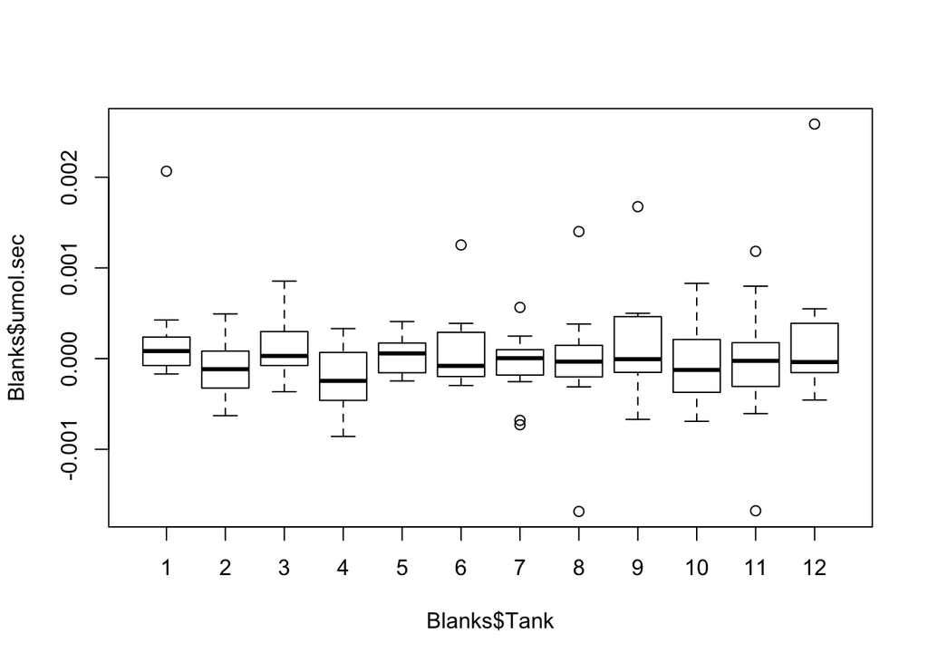

```r
#Calculate Photo blank rate
blnk <- aggregate(umol.sec ~ Date*Species*Tank*Light.or.Dark.x  , data=Data, mean)
Blanks <- subset(blnk, Species == "Blank")
Blanks$Group <- paste(Blanks$Date, Blanks$Tank, Blanks$Light.or.Dark.x, sep = "_")
boxplot(Blanks$umol.sec ~ Blanks$Tank)
```

```r
Data <- merge(Data, Blanks, by="Group")

#Account for blank rate Subtract Blank by the temperature blank
Data$umol.sec.corr <- Data$umol.sec.x-Data$umol.sec.y
```

Normalize to surface area of the coral.

```r
#normalize to surface area and h-1
Data$umol.cm2.hr <- (Data$umol.sec.corr*3600)/Data$Surface.Area
```

Removing blanks from the dataset and exporting both respirometry and photosynthetic rates.

```r
Photo <- subset(Data, Light.or.Dark.x.x=="Photo")
Photo <- subset(Photo, Species.x!="Blank")
Resp <- subset(Data, Light.or.Dark.x.x=="Resp")
Resp <- subset(Resp, Species.x!="Blank")

write.csv(Photo, file="Physiology_variables/Respirometry/Output/Photosynthesis.rates.csv")
write.csv(Resp, file="Physiology_variables/Respirometry/Output/Respiration.rates.csv")
```

Calculating gross photosynthesis (Pnet - negative Rdark)

```r
#merge desired columns by id
resp.data <- merge(Photo[,c(1,2,3,6,8,15,18,19,38)],Resp[,c(3,38)], by="Fragment.ID.x")

#rename the columns
names(resp.data)[names(resp.data) == "umol.cm2.hr.x"]<- "Pnet_umol.cm2.hr"
names(resp.data)[names(resp.data) == "umol.cm2.hr.y"] <- "Rdark_umol.cm2.hr"

# calculating Pgross
resp.data$Pgross_umol.cm2.hr <- resp.data$Pnet_umol.cm2.hr - resp.data$Rdark_umol.cm2.hr
```

BELOW IS TEMPORARY WHILE MISSING CORALS ARE TRACKED DOWN

```r
# Taking out the missing P. acuta fragments
Missing.list <- c("M-2976_20180923", "M-3003_20180923", "M-2008_20180923", "M-2512_20180923", "M-2528_20180929", "M-2740_20180929", "M-1603_20180929", "M-2200_20180929", "P-2880_20180923", "P-2752_20180923", "P-2522_20180923", "P-2523_20180923", "P-2981_20180929", "P-2984_20180929", "P-1739_20180929", "P-2859_20180929")
Missing.list <- as.list(Missing.list)
Missing <- resp.data[!grepl(paste(Missing.list, collapse = "|"), resp.data$Fragment.ID.x),]
```

Calculating means.

```r
AllMeans <- ddply(Missing, c('Date.x','Species.x', 'Treatment'), summarize,
                  #pnet
                  Pnet.mean= mean(Pnet_umol.cm2.hr, na.rm=T), #mean pnet
                  N = sum(!is.na(Pnet_umol.cm2.hr)), # sample size
                  Pnet.se = sd(Pnet_umol.cm2.hr, na.rm=T)/sqrt(N), #SE
                  #Rdark
                  Rdark.mean= mean(Rdark_umol.cm2.hr, na.rm=T), #mean rdark
                  Rdark.se = sd(Rdark_umol.cm2.hr, na.rm=T)/sqrt(N), #SE
                  #Pgross
                  Pgross.mean  = mean(Pgross_umol.cm2.hr, na.rm=TRUE),
                  Pgross.se = sd (Pgross_umol.cm2.hr, na.rm=TRUE)/sqrt(N))
AllMeans
```

```
##      Date.x   Species.x Treatment Pnet.mean N    Pnet.se Rdark.mean    Rdark.se
## 1  20180922   Montipora      ATAC 1.3701512 4 0.17107896 -0.3586793 0.057744068
## 2  20180922   Montipora      ATHC 1.4045233 2 0.09988182 -0.3470898 0.006077912
## 3  20180922   Montipora      HTAC 1.4016855 4 0.33027707 -0.7346503 0.156144130
## 4  20180922   Montipora      HTHC 1.1570876 2 0.03238499 -0.3942503 0.017279777
## 5  20180922 Pocillopora      ATAC 1.6843649 4 0.20678681 -0.4293678 0.037462706
## 6  20180922 Pocillopora      ATHC 2.0020104 2 0.34691474 -0.5395935 0.018320152
## 7  20180922 Pocillopora      HTAC 0.9844054 4 0.13952091 -0.3568737 0.029035960
## 8  20180922 Pocillopora      HTHC 1.7633604 2 0.15830024 -0.5430920 0.075333698
## 9  20180923   Montipora      ATAC 1.0861790 6 0.09316569 -0.4024839 0.032541993
## 10 20180923   Montipora      ATHC 1.3323494 4 0.04193846 -0.3902927 0.038549902
## 11 20180923   Montipora      HTAC 1.1491916 6 0.13274010 -0.3933438 0.028129481
## 12 20180923   Montipora      HTHC 2.1562524 4 0.85762803 -0.7202019 0.252363192
## 13 20180923 Pocillopora      ATAC 1.5160702 6 0.15234484 -0.3836299 0.025191534
## 14 20180923 Pocillopora      ATHC 1.7849838 4 0.12965726 -0.3720849 0.045717797
```

[output cut: 99 more lines]

```r
colnames(AllMeans) <- c("Date", "Species", "Treatment", "Pnet.mean", "N",   "Pnet.se",  "Rdark.mean",   "Rdark.se", "Pgross.mean",  "Pgross.se")
AllMeans$Group <- paste(AllMeans$Species, AllMeans$Treatment, sep = "_")

# exporting results
write.csv(resp.data, file="Physiology_variables/Respirometry/Output/Resp_AllRates.csv") # raw data
write.csv(AllMeans, file="Physiology_variables/Respirometry/Output/Resp_AllMeans.csv") # Mean data
```

Subsetting by species and changing respiration values to absolute value.

```r
# Separating by species
Pact  <- subset(AllMeans, Species=="Pocillopora")
Mcap <- subset(AllMeans, Species=="Montipora")

# Changing respiration rates to absolute values
Pact$Rdark.mean <- abs(Pact$Rdark.mean)
Mcap$Rdark.mean <- abs(Mcap$Rdark.mean)

# Changing the date column to be a factor not integer.
Mcap$Date <- as.factor(Mcap$Date)
Pact$Date <- as.factor(Pact$Date)
```

Plotting respiration and photosynthetic rates. To plot a response variable with both species on one graph, use facet_wrap(~Species) function.

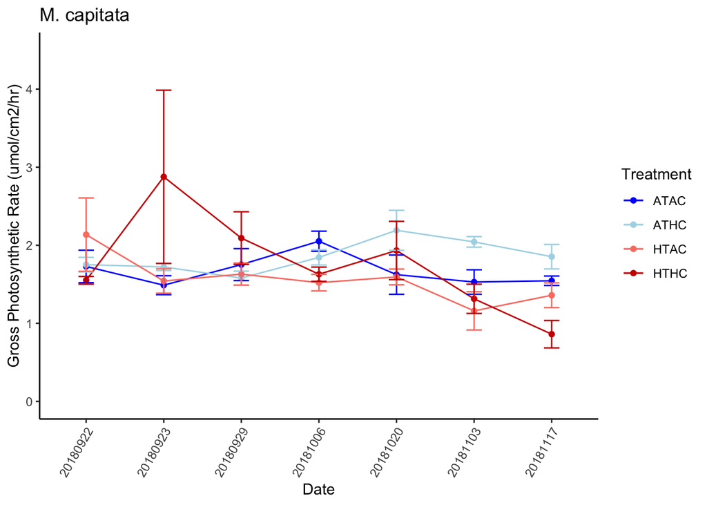

```r
colors <- c("blue", "lightblue", "salmon", "red3")

## Montipora capitata
Mcap.Pg <- ggplot(Mcap, aes(x=Date, y = Pgross.mean, group = Treatment, color = Treatment)) +
  geom_line() + geom_point() + theme_classic() +
  scale_color_manual(values = colors) +
  xlab("Date") + theme(axis.text.x=element_text(angle=60, hjust=1)) + # x-axis label and rotating text on x axis
  ylab("Gross Photosynthetic Rate (umol/cm2/hr)") + ylim(c(0, 4.5)) + # y-axis label and y axis range
  geom_errorbar(aes(ymin=Pgross.mean-Pgross.se, ymax=Pgross.mean+Pgross.se), width=.2) +
  ggtitle("M. capitata")
Mcap.Pg
```

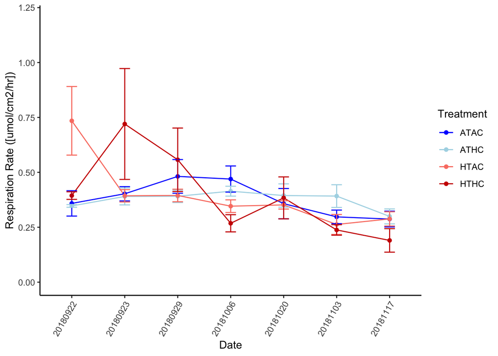

```r
Mcap.Rd <- ggplot(Mcap, aes(x=Date, y = Rdark.mean, group = Treatment, color = Treatment)) +
  geom_line() + geom_point() + theme_classic() +
  scale_color_manual(values = colors) +
  xlab("Date") + theme(axis.text.x=element_text(angle=60, hjust=1)) + # x-axis label and rotating text on x axis
  ylab("Respiration Rate ([umol/cm2/hr])") + ylim(c(0, 1.2)) + # y-axis label and y axis range
  geom_errorbar(aes(ymin=Rdark.mean-Rdark.se, ymax=Rdark.mean+Rdark.se), width=.2)
Mcap.Rd
```

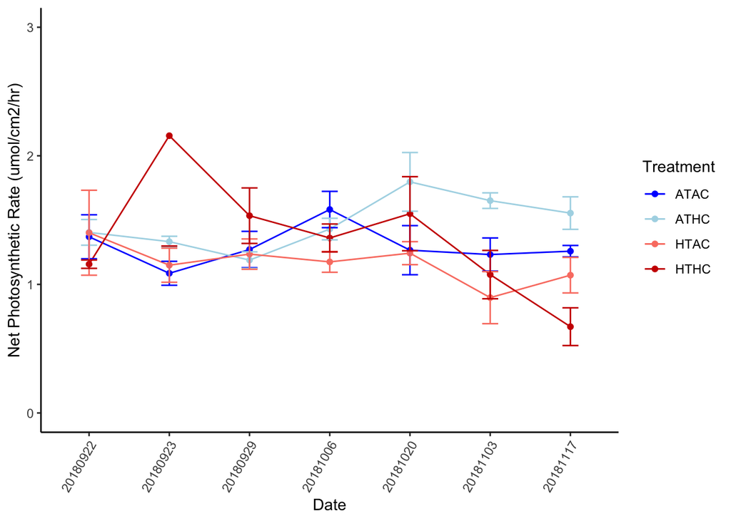

```r
Mcap.Pn <- ggplot(Mcap, aes(x=Date, y = Pnet.mean, group = Treatment, color = Treatment)) +
  geom_line() + geom_point() + theme_classic() +
  scale_color_manual(values = colors) +
  xlab("Date") + theme(axis.text.x=element_text(angle=60, hjust=1)) + # x-axis label and rotating text on x axis
  ylab("Net Photosynthetic Rate (umol/cm2/hr)") + ylim(c(0, 3)) + # y-axis label and y axis range
  geom_errorbar(aes(ymin=Pnet.mean-Pnet.se, ymax=Pnet.mean+Pnet.se), width=.2)
Mcap.Pn
```

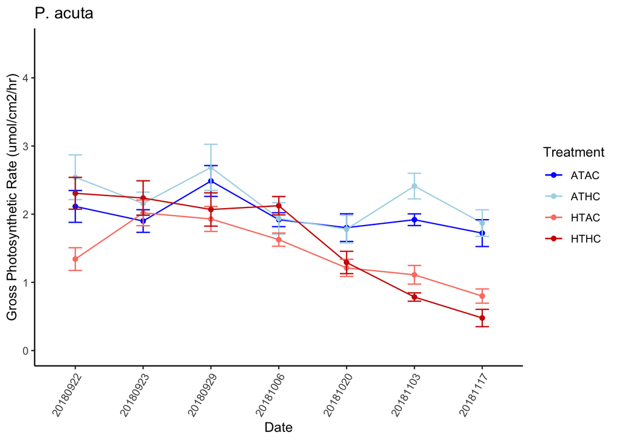

```r
## Pocillopora acuta
Pact.Pg <- ggplot(Pact, aes(x=Date, y = Pgross.mean, group = Treatment, color = Treatment)) +
  geom_line() + geom_point() + theme_classic() +
  scale_color_manual(values = colors) +
  xlab("Date") + theme(axis.text.x=element_text(angle=60, hjust=1)) + # x-axis label and rotating text on x axis
  ylab("Gross Photosynthetic Rate (umol/cm2/hr)") + ylim(c(0, 4.5)) + # y-axis label and y axis range
  geom_errorbar(aes(ymin=Pgross.mean-Pgross.se, ymax=Pgross.mean+Pgross.se), width=.2) +
  ggtitle("P. acuta")
Pact.Pg
```

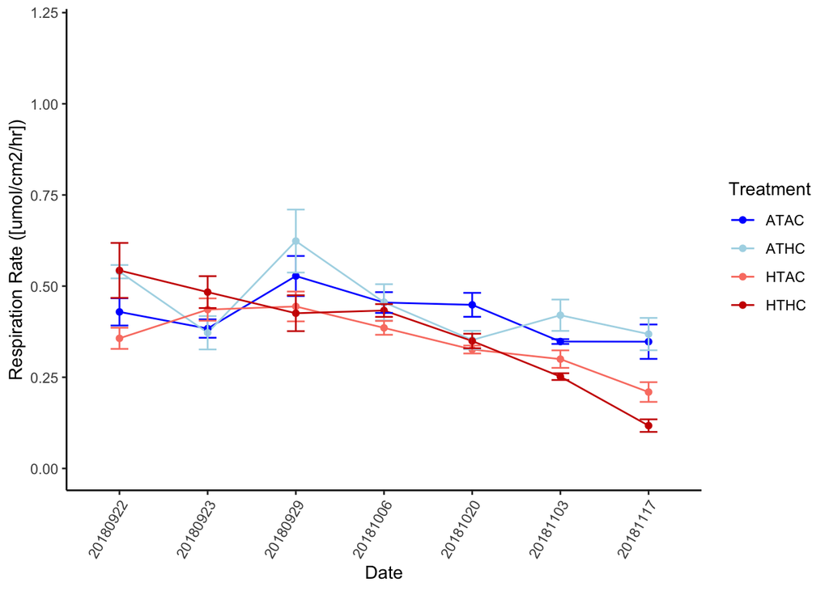

```r
Pact.Rd <- ggplot(Pact, aes(x=Date, y = Rdark.mean, group = Treatment, color = Treatment)) +
  geom_line() + geom_point() + theme_classic() +
  scale_color_manual(values = colors) +
  xlab("Date") + theme(axis.text.x=element_text(angle=60, hjust=1)) + # x-axis label and rotating text on x axis
  ylab("Respiration Rate ([umol/cm2/hr])") + ylim(c(0, 1.2)) + # y-axis label and y axis range
  geom_errorbar(aes(ymin=Rdark.mean-Rdark.se, ymax=Rdark.mean+Rdark.se), width=.2)
Pact.Rd
```

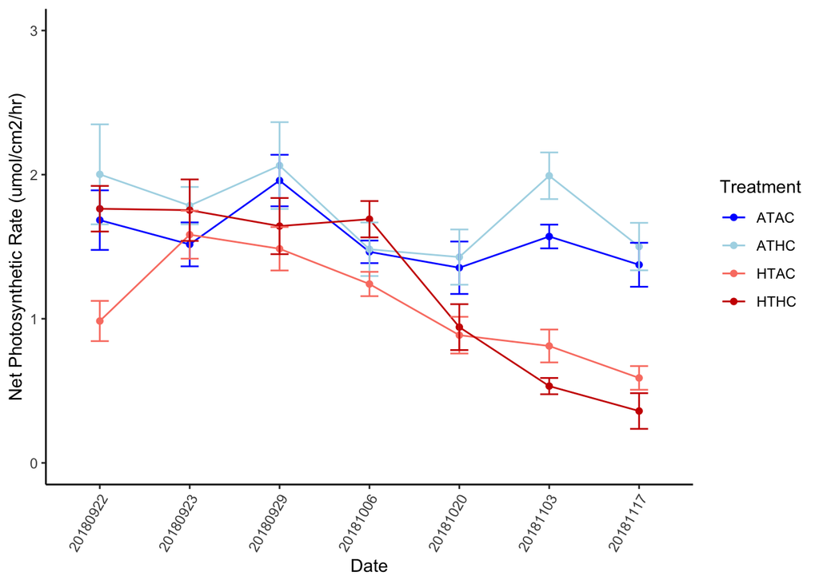

```r
Pact.Pn <- ggplot(Pact, aes(x=Date, y = Pnet.mean, group = Treatment, color = Treatment)) +
  geom_line() + geom_point() + theme_classic() +
  scale_color_manual(values = colors) +
  xlab("Date") + theme(axis.text.x=element_text(angle=60, hjust=1)) + # x-axis label and rotating text on x axis
  ylab("Net Photosynthetic Rate (umol/cm2/hr)") + ylim(c(0, 3)) + # y-axis label and y axis range
  geom_errorbar(aes(ymin=Pnet.mean-Pnet.se, ymax=Pnet.mean+Pnet.se), width=.2)
Pact.Pn
```

```r
Poc.Figs <- arrangeGrob(Pact.Pg, Pact.Rd, Pact.Pn, ncol=1)
ggsave(file="Physiology_variables/Respirometry/Output/Poc_Respirometry.pdf", Poc.Figs, width = 11, height = 10, units = c("in"))
ggsave(file="Physiology_variables/Respirometry/Output/Poc_Respirometry.jpg", Poc.Figs, width = 8, height = 6, units = c("in"))

Mont.Figs <- arrangeGrob(Mcap.Pg, Mcap.Rd, Mcap.Pn, ncol=1)
ggsave(file="Physiology_variables/Respirometry/Output/Mont_Respirometry.pdf", Mont.Figs, width = 11, height = 10, units = c("in"))
ggsave(file="Physiology_variables/Respirometry/Output/Mont_Respirometry.jpg", Mont.Figs, width = 8, height = 6, units = c("in"))

Resp.Figs <- arrangeGrob(Mcap.Pg, Pact.Pg, Mcap.Rd, Pact.Rd, Mcap.Pn, Pact.Pn, ncol=2)
ggsave(file="Physiology_variables/Respirometry/Output/Respirometry.pdf", Resp.Figs, width = 11, height = 10, units = c("in"))
ggsave(file="Physiology_variables/Respirometry/Output/Respirometry.jpg", Resp.Figs, width = 11, height = 10, units = c("in"))
```

Statistical analyses.

```r
Mcap.All <- subset(resp.data, Species.x=="Montipora")
Pact.All  <- subset(resp.data, Species.x=="Pocillopora")

## P. acuta
# Net Photosynthetic Rates
Pact.Pnet.aov <- aov(Pnet_umol.cm2.hr ~ Treatment*Date.x, data = Pact.All)
summary(Pact.Pnet.aov)
```

```
##                   Df Sum Sq Mean Sq F value   Pr(>F)
## Treatment          3  8.982   2.994   19.43 1.21e-10 ***
## Date.x             1  8.743   8.743   56.73 4.92e-12 ***
## Treatment:Date.x   3  5.170   1.723   11.18 1.21e-06 ***
## Residuals        145 22.346   0.154
## ---
## Signif. codes:  0 '***' 0.001 '**' 0.01 '*' 0.05 '.' 0.1 ' ' 1
```

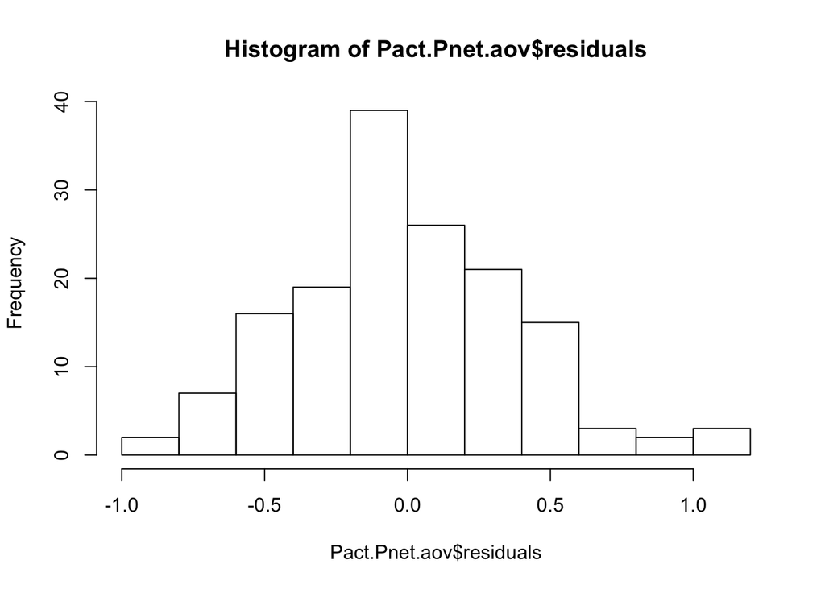

```r
#TukeyHSD(Pact.Pnet.aov)

hist(Pact.Pnet.aov$residuals)
```

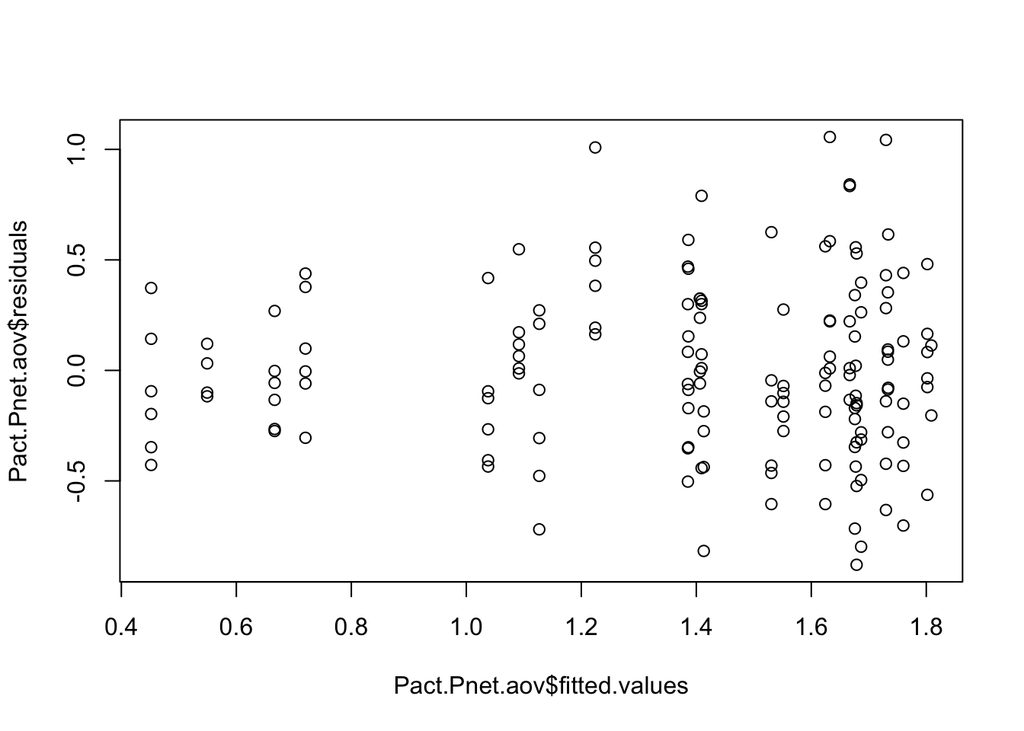

```r
plot(Pact.Pnet.aov$fitted.values, Pact.Pnet.aov$residuals)
```

```r
shapiro.test(Pact.Pnet.aov$residuals)
```

```
##
##  Shapiro-Wilk normality test
##
## data:  Pact.Pnet.aov$residuals
## W = 0.98993, p-value = 0.3451
```

```r
# Gross Photosynthetic Rates
Pact.Pgross.aov <- aov(Pgross_umol.cm2.hr ~ Treatment*Date.x, data = Pact.All)
summary(Pact.Pgross.aov)
```

```
##                   Df Sum Sq Mean Sq F value   Pr(>F)
## Treatment          3 11.636   3.879   18.48 3.30e-10 ***
## Date.x             1 14.162  14.162   67.47 1.08e-13 ***
## Treatment:Date.x   3  7.346   2.449   11.67 6.81e-07 ***
## Residuals        145 30.435   0.210
## ---
## Signif. codes:  0 '***' 0.001 '**' 0.01 '*' 0.05 '.' 0.1 ' ' 1
```

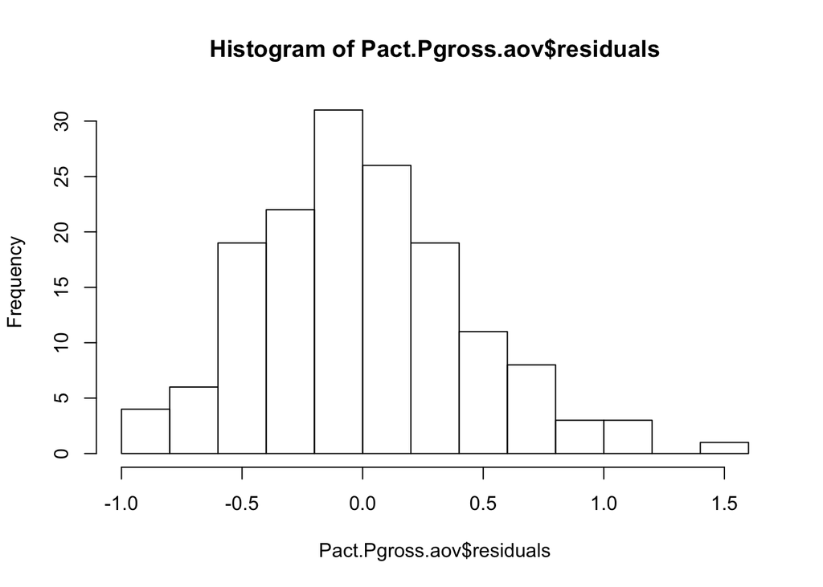

```r
#TukeyHSD(Pact.Pgross.aov)

hist(Pact.Pgross.aov$residuals)
```

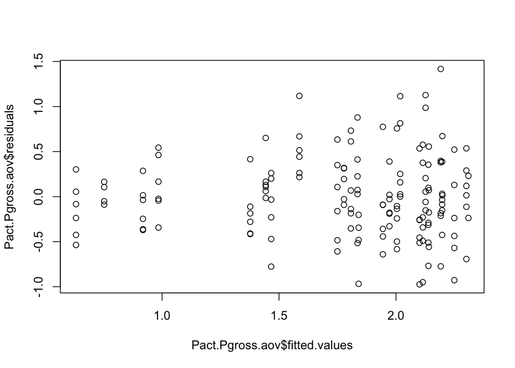

```r
plot(Pact.Pgross.aov$fitted.values, Pact.Pgross.aov$residuals)
```

```r
shapiro.test(Pact.Pgross.aov$residuals)
```

```
##
##  Shapiro-Wilk normality test
##
## data:  Pact.Pgross.aov$residuals
## W = 0.98688, p-value = 0.1588
```

```r
# Dark Respiration Rates
Pact.Rdark.aov <- aov(Rdark_umol.cm2.hr ~ Treatment*Date.x, data = Pact.All)
summary(Pact.Rdark.aov)
```

```
##                   Df Sum Sq Mean Sq F value   Pr(>F)
## Treatment          3 0.1758  0.0586   6.425 0.000408 ***
## Date.x             1 0.6503  0.6503  71.285 2.92e-14 ***
## Treatment:Date.x   3 0.1939  0.0646   7.087 0.000178 ***
## Residuals        145 1.3227  0.0091
## ---
## Signif. codes:  0 '***' 0.001 '**' 0.01 '*' 0.05 '.' 0.1 ' ' 1
```

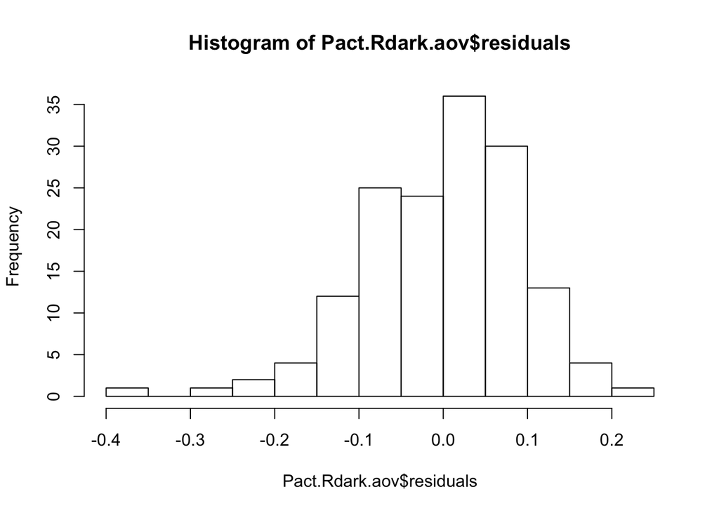

```r
#TukeyHSD(Pact.Rdark.aov)

hist(Pact.Rdark.aov$residuals)
```

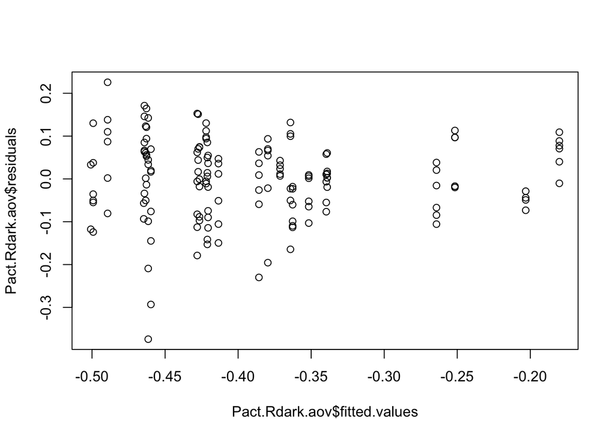

```r
plot(Pact.Rdark.aov$fitted.values, Pact.Rdark.aov$residuals)
```

```r
shapiro.test(Pact.Rdark.aov$residuals)
```

```
##
##  Shapiro-Wilk normality test
##
## data:  Pact.Rdark.aov$residuals
## W = 0.97456, p-value = 0.006191
```

```r
## M. capitata
# Net Photosynthetic Rates
Mcap.Pnet.aov <- aov(log10(Pnet_umol.cm2.hr) ~ Treatment*Date.x, data = Mcap.All)
summary(Mcap.Pnet.aov)
```

```
##                   Df Sum Sq Mean Sq F value   Pr(>F)
## Treatment          3 0.2665 0.08884   4.628  0.00403 **
## Date.x             1 0.0515 0.05147   2.681  0.10371
## Treatment:Date.x   3 0.4454 0.14846   7.734 7.95e-05 ***
## Residuals        144 2.7641 0.01920
## ---
## Signif. codes:  0 '***' 0.001 '**' 0.01 '*' 0.05 '.' 0.1 ' ' 1
```

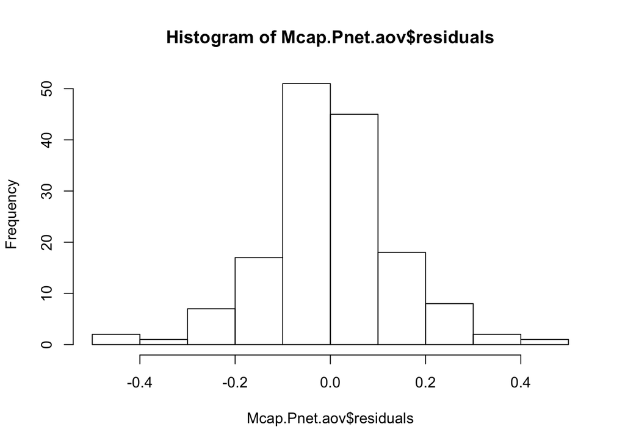

```r
#TukeyHSD(Mcap.Pnet.aov)

hist(Mcap.Pnet.aov$residuals)
```

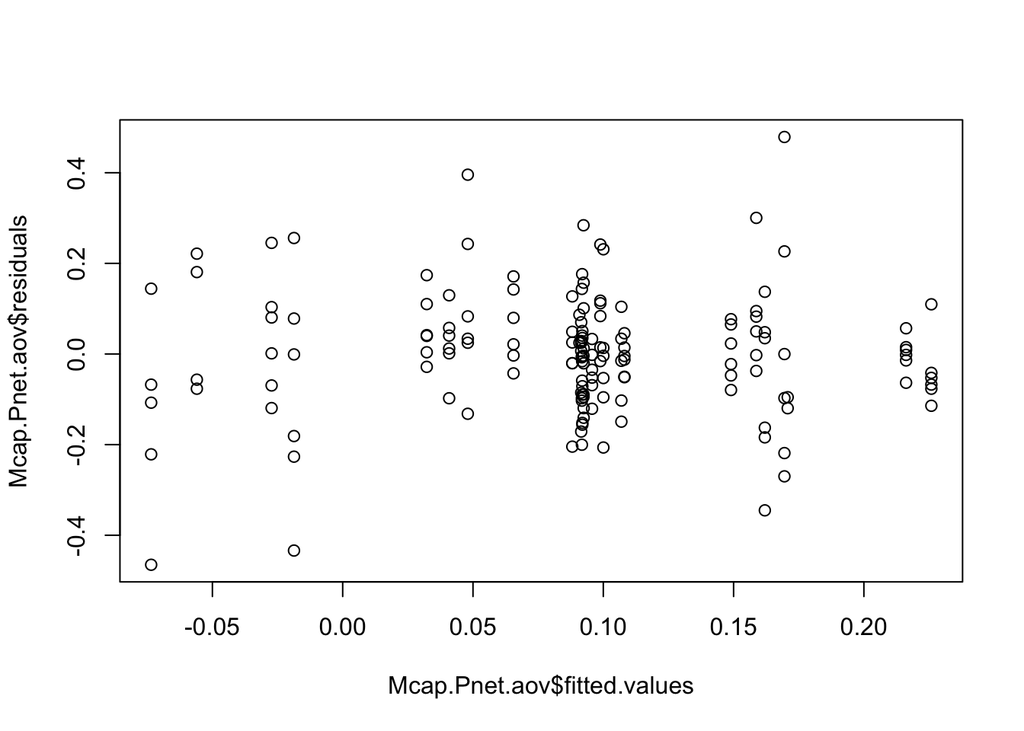

```r
plot(Mcap.Pnet.aov$fitted.values, Mcap.Pnet.aov$residuals)
```

```r
shapiro.test(Mcap.Pnet.aov$residuals)
```

```
##
##  Shapiro-Wilk normality test
##
## data:  Mcap.Pnet.aov$residuals
## W = 0.9716, p-value = 0.003098
```

```r
# Gross Photosynthetic Rates
Mcap.Pgross.aov <- aov(log10(Pgross_umol.cm2.hr) ~ Treatment*Date.x, data = Mcap.All)
summary(Mcap.Pgross.aov)
```

```
##                   Df Sum Sq Mean Sq F value   Pr(>F)
## Treatment          3 0.1818 0.06062   3.527  0.01660 *
## Date.x             1 0.1476 0.14763   8.589  0.00393 **
## Treatment:Date.x   3 0.4219 0.14062   8.181 4.57e-05 ***
## Residuals        144 2.4751 0.01719
## ---
## Signif. codes:  0 '***' 0.001 '**' 0.01 '*' 0.05 '.' 0.1 ' ' 1
```

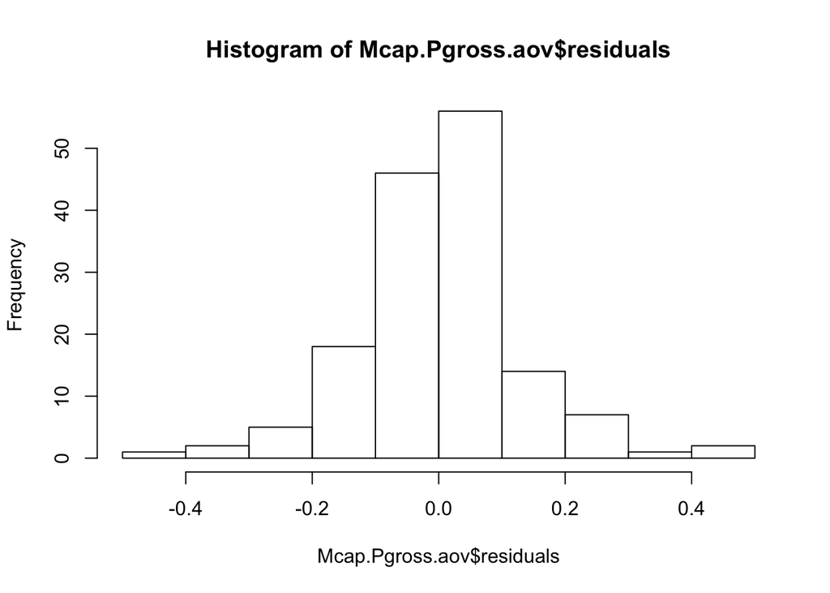

```r
#TukeyHSD(Mcap.Pgross.aov)

hist(Mcap.Pgross.aov$residuals)
```

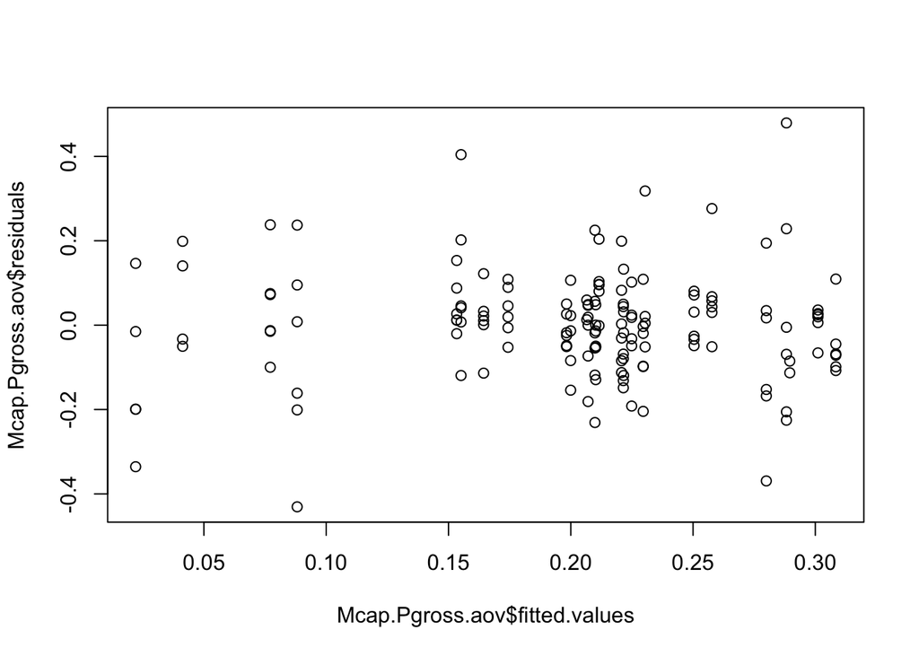

```r
plot(Mcap.Pgross.aov$fitted.values, Mcap.Pgross.aov$residuals)
```

```r
shapiro.test(Mcap.Pgross.aov$residuals)
```

```
##
##  Shapiro-Wilk normality test
##
## data:  Mcap.Pgross.aov$residuals
## W = 0.96467, p-value = 0.000613
```

```r
# Dark Respiration Rates
Mcap.Rdark.aov <- aov(Rdark_umol.cm2.hr ~ Treatment*Date.x, data = Mcap.All)
summary(Mcap.Rdark.aov)
```

```
##                   Df Sum Sq Mean Sq F value Pr(>F)
## Treatment          3  0.003  0.0011   0.042 0.9885
## Date.x             1  0.664  0.6640  26.126  1e-06 ***
## Treatment:Date.x   3  0.276  0.0919   3.617 0.0148 *
## Residuals        144  3.660  0.0254
## ---
## Signif. codes:  0 '***' 0.001 '**' 0.01 '*' 0.05 '.' 0.1 ' ' 1
```

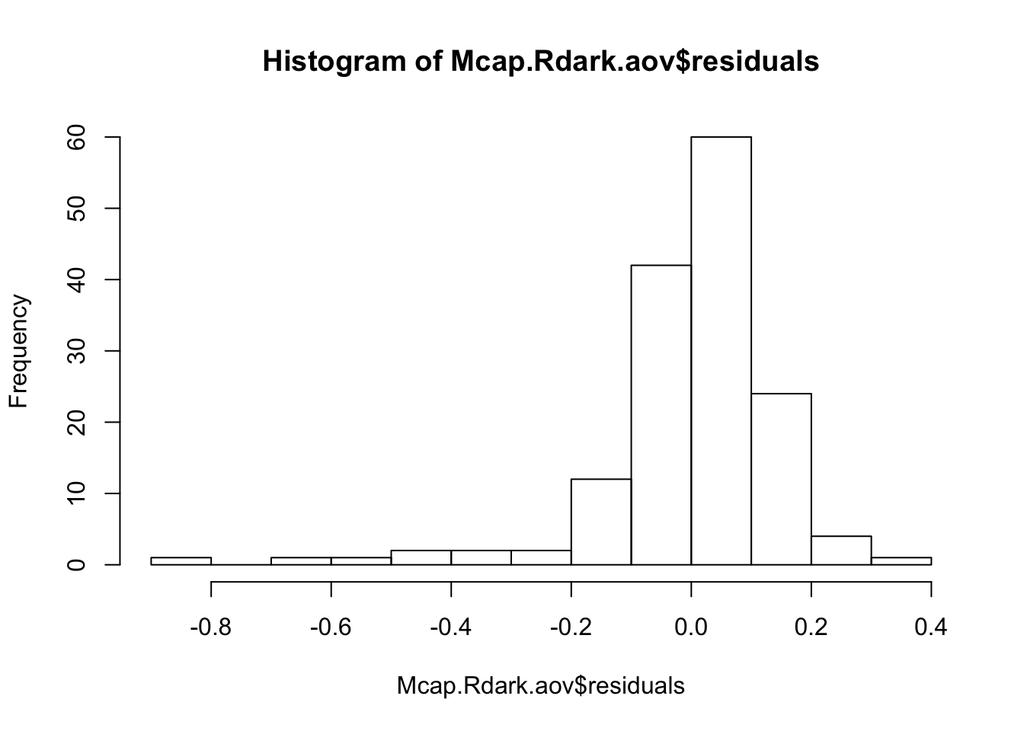

```r
#TukeyHSD(Mcap.Rdark.aov)

hist(Mcap.Rdark.aov$residuals)
```

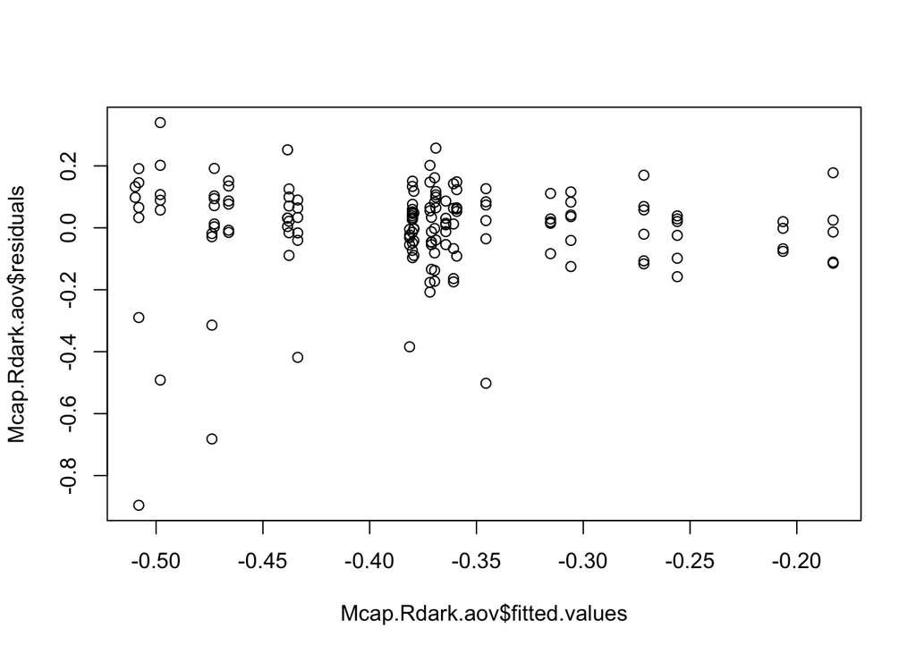

```r
plot(Mcap.Rdark.aov$fitted.values, Mcap.Rdark.aov$residuals)
```

```r
shapiro.test(Mcap.Rdark.aov$residuals)
```

```
##
##  Shapiro-Wilk normality test
##
## data:  Mcap.Rdark.aov$residuals
## W = 0.81084, p-value = 9.667e-13
```